# 2016年美国共享单车活动快照

## 进行你自己的分析

到目前为止，你已经对手头的数据进行了初步的探索，对比了三座美国城市的相应骑行量，以及会员和散客的骑行比例，你还选取了其中一座城市，从一般骑行时长的角度来研究会员和散客的区别，接下来的探索，你就要自己选择研究方向了，以下是一些探索方向的建议：

- 不同月份或季度的骑客量有什么区别？哪个月份/季度的骑客量最高？会员骑行量与散客骑行量之比会受月份或季度的影响吗？
- 周末和工作日的系统用户骑行模式有何区别？哪一天会员更可能使用骑行系统？散客呢？平均骑行时长会受一周内不同日期的影响吗？
- 一天内的哪个时候系统使用最频繁？会员和散客的使用模式有区别吗？

若你在问题 1 回答中提出的任何问题与上述参考类似，那现在就是研究这些的好时机。作为研究的一部分，你需要创建可视化界面，如果不想创建直方图，你可以参考 [Pyplot 文件](https://matplotlib.org/devdocs/api/pyplot_summary.html)。值得一提的是，如果你想为分类变量的不同值绘制统计图（如城市、用户类型），柱形图会大有帮助。[`.bar()`文件页面](https://matplotlib.org/devdocs/api/_as_gen/matplotlib.pyplot.bar.html#matplotlib.pyplot.bar)底部具备相关示例链接，可供你参考，助你创建自己需要的统计图。

**问题 6**：探索另一个可用数据回答的问题，继续研究。在下方写下你想探索的问题，你的研究至少应包括两个变量，对比两组数据并使用一个可视化界面。

**答案**:

1、纽约不同季度和月份骑客量

①季度：纽约骑客量人数在四个城市中最多，最高月份骑行人次达30000多。纽约不同月份和季度的骑客量不相同，受季节影响明显。第三季度骑客量最高，第一季度骑客量最低。秋季骑行人数最多，冬季最少。

④会员和散客骑客量的比较：散客的骑客量在12月、1月、2月骤减，会员的骑客量在此三个月比平时有所减少，但幅度平缓没有散客骑客量减少幅度大。由之前的结论知，散客的骑行时长比较长，一般超过30分钟，骑行路程较远。所以冬季选择骑车出行较远路程的人数大幅减少。

2、旧金山不同季度和月份骑客量

①季度：旧金山总的骑客量很少，最高月份骑行人次仅600多。不同月份和季度的骑客量略有不同，增减变化受季节影响不大。第二、三季度骑客量最高，第一、四季度骑客量略低。

②骑客总量：其中骑客总量10月达最高峰值600多，2-11月骑客总量基本相同都在500-600人次之间。1月和12月的骑客总量最少但也在400人次左右。全年各月份骑客总量变化不大，冬季略有下降。

③会员骑客量、散客骑客量：会员骑客量基本每月在450-500人次左右。12月和1月350人次。散客骑客量最多每月不超过100人次，大多在40-80人次左右。12月、1月最少，30人次左右。

3、芝加哥和华盛顿不同季度和月份骑客量的比较

①芝加哥和华盛顿骑客总量在四个城市中居中，并且骑客总量差不多，所以那两个城市做比较。

芝加哥的骑客总量，6-8月份时，10000人次左右。9月份9000人次。5、10月份，8000人次左右。3、4、11月份，4000人次。1、2、12月，2000人次。

③华盛顿的骑客总量，3-11月，在6000-8000之间。12、1、2月在3000人次左右。

芝加哥的骑客总量在在5-10月份高于华盛顿，华盛顿的骑客总量在11-4月高于芝加哥。

华盛顿会员与散客的骑客量比，7月最高2.5:1。 6、8、9、10月 3.5:1。3、4、5、11月4:1。 12月6:1。1、2月8:1。

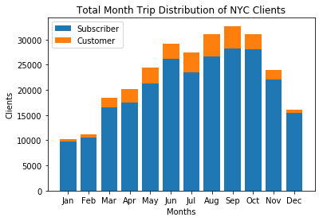

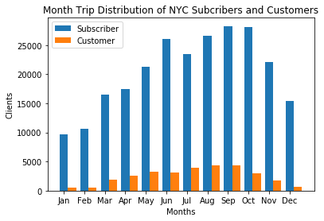

```python
## 使用本框及新框来继续探索数据集。 ##
## 一旦你进行了自己的探索，请写下你的发现 ##
## 请将发现写在上方的 Markdown 框中。                                     ##

## 使用本框及新框来继续探索数据集，回答问题6。 ##
# 不同月份或季度的骑客量有什么区别？哪个月份/季度的骑客量最高？会员骑行量与散客骑行量之比会受月份或季度的影响吗？
## 使用 pyplot 函数来为顾客骑行量和月份的关系生成条形图。 ##
def month_distribution(filename):
    """
    本函数会读取一个骑行数据文件，报告
    顾客骑行量的月份分布
    """
    with open(filename, 'r') as f_in:
        # 设置 csv reader 对象
        reader = csv.DictReader(f_in)

        # 初始化计数变量
        # 字典的fromkeys函数用于创建一个新字典，dict.fromkeys(seq[, value])，以序列seq中元素做字典的键
        # value为字典所有键对应的初始值，value 是可选参数, 若dict.fromkeys(seq)，则value字典所有键对应的初始值为None
        # range(1,13)是从1开始，包括1，到12，包括12
        """
        第一种以往学习的写法
        “
        month=[]
        for i in range(1,13):
            month.append(i)
        ”
        """
        """
        第二种新掌握的写法
        “
        month=[i for i in range(1,13)]
        ”
        """
        # 使用第二种写法
        month=[i for i in range(1,13)]

        # 设置列表month=[1,2,3,4,5,6,7,8,9,10,11,12],month中值做字典dict_month_s和dict_month_c的键值
        dict_month_s=dict.fromkeys(month,0)
        dict_month_c=dict.fromkeys(month,0)

        # 分别计算会员和散客每个月的骑行人数
        for row in reader:
            if row['user_type']=='Subscriber':
                # row['month']为字符串格式，int()转换为整数
                # 从1到12读取月份，月份若为8，则相应的字典的第八个items的key加1，即八月的骑行人数加1
                for i in range(1,13):
                    if int(row['month'])==i:
                        dict_month_s[i]+=1


            elif row['user_type']=='Customer':
                for i in range(1,13):
                    if int(row['month'])==i:
                        dict_month_c[i]+=1

        data_s=[]
        data_c=[]
        for i in range(1,13):
            # 从1到12的顺序读取字典的键值，分别把相应字典的键值添加到data_s和data_c列表
            data_s.append(dict_month_s[i])
            data_c.append(dict_month_c[i])
        return(data_s,data_c)

# 调用函数得纽约的数据
n_data_s,n_data_c=month_distribution('./data/NYC-2016-Summary.csv')


# 设置绘制条形的参数，条形图是用条形的长度表示各类别频数的多少，其宽度表示类别
# x的个数即列表中值的个数，x先设置为0-11的十二个数，稍后更改横轴刻度标签
# 条形图的高度分别带入a和b，给a赋值会员的数据列表，给b赋值散客的数据列表
x = range(len(n_data_s))
a = n_data_s
b = n_data_c

# 设置横轴刻度标签辅助变量为月份的简写
labels = ['Jan', 'Feb', 'Mar', 'Apr', 'May','Jun', 'Jul', 'Aug', 'Sep', 'Oct','Nov','Dec']

# 带入条形图参数
# 设置代表两条条形图的图例标签参数为Subscriber和Customer，通过plt.legend()输出图例
# 设置横轴的刻度标签为月份，表示不同月份类别
# 下边的柱表示Subscriber会员数据，堆叠的上边的状表示Customer散客的数据。
# 用堆叠条状图显示，整根调状图表示各个月份骑行量会员和散客的总数据。#颜色区分来堆叠，会员和散客的比较数据更直观。
plt.bar(x, a, label='Subscriber',tick_label=labels)
plt.bar(x, b, bottom=a, label='Customer',tick_label=labels)
plt.legend()


# 设置图总标题:纽约客户总月份骑行量分布图
plt.title('Total Month Trip Distribution of NYC Clients')

# 设置横轴（X轴）标签为：月份
plt.xlabel('Months')

# 设置纵轴（Y轴）标签为：顾客数
plt.ylabel('Clients')

# 呈现堆叠条形图
plt.show()



### 设置此单元格中的第二个条状图

# 导入numpy模块，辅助完成x设置
import numpy as np

# x先设置为0-11的十二个数，稍后更改横轴刻度标签
size = 12
x = np.arange(size)

# 设置并列条柱的起始位置参数的辅助变量
total_width, n = 0.8, 2
width = total_width / n

# 设置横轴刻度标签辅助变量为月份的简写
labels = ['Jan', 'Feb', 'Mar', 'Apr', 'May','Jun', 'Jul', 'Aug', 'Sep', 'Oct','Nov','Dec']

# 带入并列条形图参数
# 设置代表两条条形图的图例标签参数为Subscriber和Customer，通过plt.legend()输出图例
# 设置横轴的刻度标签为月份，表示不同月份类别。用tick_label=labels来设置，则标签的起始位置为x的中点
# 两条柱共占比0.8宽度，则每条柱占比0.4。第二条柱起始位置在第一条柱向右偏移0.4，即紧挨着第一条柱并列。
# 第一条柱表示Subscriber会员数据，并列的第二条状表示Customer散客的数据。
# 用并列条状图显示，会员和散客的比较数据更直观。
plt.bar(x, a,  width=width, label='Subscriber',tick_label=labels)
plt.bar(x + width, b, width=width, label='Customer')
plt.legend()

# 设置图总标题:纽约会员和散客的月份骑行量分布图
plt.title('Month Trip Distribution of NYC Subcribers and Customers')

# 设置横轴（X轴）标签为：月份
plt.xlabel('Months')

# 设置纵轴（Y轴）标签为：顾客数
plt.ylabel('Clients')

# 呈现并列条形图
plt.show()
```

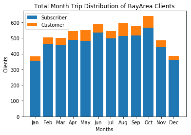

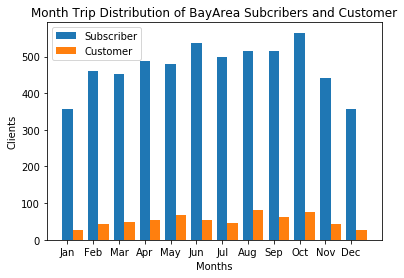

```python
# 调用函数得旧金山的数据
s_data_s,s_data_c=month_distribution('./examples/BayArea-Y3-Summary.csv')


# 设置绘制条形的参数，条形图是用条形的长度表示各类别频数的多少，其宽度表示类别
# x的个数即列表中值的个数，x先设置为0-11的十二个数，稍后更改横轴刻度标签
# 条形图的高度分别带入a和b，给a赋值会员的数据列表，给b赋值散客的数据列表
x = range(len(s_data_s))
a = s_data_s
b = s_data_c

# 设置横轴刻度标签辅助变量为月份的简写
labels = ['Jan', 'Feb', 'Mar', 'Apr', 'May','Jun', 'Jul', 'Aug', 'Sep', 'Oct','Nov','Dec']

# 带入条形图参数
# 设置代表两条条形图的图例标签参数为Subscriber和Customer，通过plt.legend()输出图例
# 设置横轴的刻度标签为月份，表示不同月份类别
# 下边的柱表示Subscriber会员数据，堆叠的上边的状表示Customer散客的数据。
# 用堆叠条状图显示，整根调状图表示各个月份骑行量会员和散客的总数据。#颜色区分来堆叠，会员和散客的比较数据更直观。
plt.bar(x, a, label='Subscriber',tick_label=labels)
plt.bar(x, b, bottom=a, label='Customer',tick_label=labels)
plt.legend()


# 设置图总标题:旧金山湾区客户总月份骑行量分布图
plt.title('Total Month Trip Distribution of BayArea Clients')

# 设置横轴（X轴）标签为：月份
plt.xlabel('Months')

# 设置纵轴（Y轴）标签为：顾客数
plt.ylabel('Clients')

# 呈现堆叠条形图
plt.show()



### 设置此单元格中的第二个条状图


# x先设置为0-11的十二个数，稍后更改横轴刻度标签
size = 12
x = np.arange(size)

# 设置并列条柱的起始位置参数的辅助变量
total_width, n = 0.8, 2
width = total_width / n

# 设置横轴刻度标签辅助变量为月份的简写
labels = ['Jan', 'Feb', 'Mar', 'Apr', 'May','Jun', 'Jul', 'Aug', 'Sep', 'Oct','Nov','Dec']

# 带入并列条形图参数
# 设置代表两条条形图的图例标签参数为Subscriber和Customer，通过plt.legend()输出图例
# 设置横轴的刻度标签为月份，表示不同月份类别。用tick_label=labels来设置，则标签的起始位置为x的中点
# 两条柱共占比0.8宽度，则每条柱占比0.4。第二条柱起始位置在第一条柱向右偏移0.4，即紧挨着第一条柱并列。
# 第一条柱表示Subscriber会员数据，并列的第二条状表示Customer散客的数据。
# 用并列条状图显示，会员和散客的比较数据更直观。
plt.bar(x, a,  width=width, label='Subscriber',tick_label=labels)
plt.bar(x + width, b, width=width, label='Customer')
plt.legend()

# 设置图总标题:旧金山湾区会员和散客的月份骑行量分布图
plt.title('Month Trip Distribution of BayArea Subcribers and Customer')

# 设置横轴（X轴）标签为：月份
plt.xlabel('Months')

# 设置纵轴（Y轴）标签为：顾客数
plt.ylabel('Clients')

# 呈现并列条形图
plt.show()
```

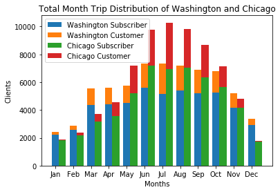

[figure not shown]

```python
# 调用函数得华盛顿的数据
w_data_s,w_data_c=month_distribution('data/Washington-2016-Summary.csv')
# 调用函数得芝加哥的数据
c_data_s,c_data_c=month_distribution('./data/Chicago-2016-Summary.csv')


# 设置绘制条形的参数，条形图是用条形的长度表示各类别频数的多少，其宽度表示类别

# x的个数即列表中值的个数，x先设置为0-11的十二个数，稍后更改横轴刻度标签
# 条形图的高度分别带入a和b，给a赋值华盛顿会员的数据列表，给b赋值华盛顿散客的数据列表
x = range(len(n_data_s))
a = w_data_s
b = w_data_c

# 设置横轴刻度标签辅助变量为月份的简写
labels = ['Jan', 'Feb', 'Mar', 'Apr', 'May','Jun', 'Jul', 'Aug', 'Sep', 'Oct','Nov','Dec']

# 带入条形图参数
# 设置a,b代表两条条形图的图例标签参数为Washington Subscriber和Washington Customer，通过后边的plt.legend()和c,d图例一起输出
# 设置横轴的刻度标签为月份，表示不同月份类别
# 下边的柱表示Subscriber会员数据，堆叠的上边的状表示Customer散客的数据。
# 用堆叠条状图显示，整根调状图表示各个月份骑行量会员和散客的总数据。#颜色区分来堆叠，会员和散客的比较数据更直观。
plt.bar(x, a,width=0.4, label='Washington Subscriber',tick_label=labels)
plt.bar(x, b, bottom=a, width=0.4,label='Washington Customer')

# x先设置为0-11的十二个数，稍后更改横轴刻度标签
# 因为a,b中对应x是通过范围函数range得。c,d中x+0.4，range得的值不能与float类型求和，所以c,d通过numpy模块重新给对应x赋值
size = 12
x = np.arange(size)

# 条形图的高度分别带入c和d，给c赋值芝加哥会员的数据列表，给d赋值芝加哥散客的数据列表
c = c_data_s
d = c_data_c

# 设置c,b代表两条条形图的图例标签参数为Chicago Subscriber和Chicago Customer，通过plt.legend()和a,b图例一起输出
plt.bar(x + 0.4, c,  width=0.4, label='Chicago Subscriber')
plt.bar(x + 0.4,d,bottom=c, width=0.4, label='Chicago Customer')
plt.legend()



# 设置图总标题:客户总月份骑行量分布图
plt.title('Total Month Trip Distribution of Washington and Chicago')

# 设置横轴（X轴）标签为：月份
plt.xlabel('Months')

# 设置纵轴（Y轴）标签为：顾客数
plt.ylabel('Clients')

# 呈现堆叠并列条形图
plt.show()



### 设置此单元格中的第二个条状图
# 调用函数得华盛顿的数据
w_data_s,w_data_c=month_distribution('data/Washington-2016-Summary.csv')
# 调用函数得芝加哥的数据
c_data_s,c_data_c=month_distribution('./data/Chicago-2016-Summary.csv')

# x的个数即列表中值的个数，x先设置为0-11的十二个数，稍后更改横轴刻度标签
# 条形图的高度分别带入a和b，给a赋值华盛顿会员的数据列表，给b赋值华盛顿散客的数据列表，给c赋值芝加哥会员的数据列表，给d赋值芝加哥散客的数据列表
x = range(len(n_data_s))
a = w_data_s
b = w_data_c
# x先设置为0-11的十二个数，稍后更改横轴刻度标签
size = 12
x = np.arange(size)
c = c_data_s
d = c_data_c

# 设置并列条柱的起始位置参数的辅助变量
total_width, n = 0.8, 4
width = total_width / n

# 设置横轴刻度标签辅助变量为月份的简写
labels = ['Jan', 'Feb', 'Mar', 'Apr', 'May','Jun', 'Jul', 'Aug', 'Sep', 'Oct','Nov','Dec']

# 带入并列条形图参数
# 设置代表四条条形图的图例标签参数为Subscriber和Customer，通过plt.legend()输出图例
# 设置横轴的刻度标签为月份，表示不同月份类别。用tick_label=labels来设置，则标签的起始位置为x的中点
# 四条柱共占比0.8宽度，则每条柱占比0.2。第二条柱起始位置在第一条柱向右偏移0.2，即紧挨着第一条柱并列，以此类推。
# 用并列条状图显示，芝加哥华盛顿，会员和散客的比较数据更直观。

plt.bar(x, a,  width=width, label='Washington Subscriber',tick_label=labels)
plt.bar(x + width, b, width=width, label='Washington Customer')
plt.bar(x + width*2, c, width=width, label='Chicago Customer')
plt.bar(x + width*3, d, width=width, label='Chicago Customer')

plt.legend()

# 设置图总标题:华盛顿和芝加哥，会员和散客的月份骑行量分布图
plt.title('Month Trip Distribution of Washington and Chicago,Subcribers and Customer')

# 设置横轴（X轴）标签为：月份
plt.xlabel('Months')

# 设置纵轴（Y轴）标签为：顾客数
plt.ylabel('Clients')

# 呈现并列条形图
plt.show()
```

**纽约**

周末和工作日的系统用户骑行模式

①会员在周末每个休息日的骑行量约占一周的10%，每个工作日的骑行量约占一周的15%。

周末每天的骑行量比工作日每天的骑行量稍少，工作日的骑行量是休息日的1.5倍。

②散客在周末每个休息日的骑行量约占一周的23%，每个工作日的骑行量约占一周的10%。

周末每天的骑行量是工作日每天的骑行量的2倍稍多。

散客周末随机使用共享单车出行的人数较多。散客周六和周日使用共享单车的总量占一周使用总量的45%。

```python
## 使用本框及新框来继续探索数据集。回答上单元格中问题 ##
## 请将发现写在上方的 Markdown 框中。                                     ##

# 周末和工作日的系统用户骑行模式有何区别？哪一天会员更可能使用骑行系统？散客呢？平均骑行时长会受一周内不同日期的影响吗？
## 使用 pyplot 函数来为顾客骑行量和星期的关系生成条形图。 ##
def week_distribution(filename):
    """
    本函数会读取一个骑行数据文件，报告
    顾客骑行量的月份分布
    """
    with open(filename, 'r') as f_in:
        # 设置 csv reader 对象
        reader = csv.DictReader(f_in)

        # 初始化计数变量
        """
        第一种写法“
        week=[]
        for i in range(1,8):
            week.append(i)
        ”
        第二种写法“
        week=[i for i in range(1,8)]
        ”
        """
        # 使用第二种写法
        week=[i for i in range(1,8)]
        dict_week_s=dict.fromkeys(week,0)
        dict_week_c=dict.fromkeys(week,0)

        # 分别计算会员和散客每个月的骑行人数
        for row in reader:
            if row['user_type']=='Subscriber':
                if row['day_of_week']=='Monday':
                    dict_week_s[1]+=1
                elif row['day_of_week']=='Tuesday':
                    dict_week_s[2]+=1
                elif row['day_of_week']=='Wednesday':
                    dict_week_s[3]+=1
                elif row['day_of_week']=='Thursday':
                    dict_week_s[4]+=1
                elif row['day_of_week']=='Friday':
                    dict_week_s[5]+=1
                elif row['day_of_week']=='Saturday':
                    dict_week_s[6]+=1
                elif row['day_of_week']=='Sunday':
                    dict_week_s[7]+=1

            elif row['user_type']=='Customer':
                if row['day_of_week']=='Monday':
                    dict_week_c[1]+=1
                elif row['day_of_week']=='Tuesday':
                    dict_week_c[2]+=1
                elif row['day_of_week']=='Wednesday':
                    dict_week_c[3]+=1
                elif row['day_of_week']=='Thursday':
                    dict_week_c[4]+=1
                elif row['day_of_week']=='Friday':
                    dict_week_c[5]+=1
                elif row['day_of_week']=='Saturday':
                    dict_week_c[6]+=1
                elif row['day_of_week']=='Sunday':
                    dict_week_c[7]+=1
        data_s=[]
        data_c=[]
        for i in range(1,8):
            data_s.append(dict_week_s[i])
            data_c.append(dict_week_c[i])
        return(data_s,data_c)

# 调用函数得纽约的数据
n_data_s,n_data_c=week_distribution('./data/NYC-2016-Summary.csv')
```

```python
print(n_data_c)
```

```
[3620, 2833, 3152, 3065, 3670, 7069, 6776]
```

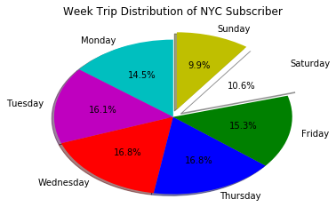

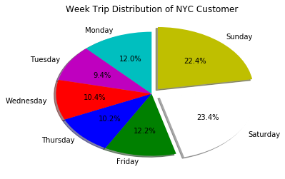

```python
# 设置饼图参数辅助赋值变量
# 把调用函数得饼图数据赋值给x的变量slices_s
slices_s = n_data_s

# 设置每个切片的标签labels的值
activities =[ 'Monday','Tuesday','Wednesday','Thursday','Friday','Saturday','Sunday']
# 设置每个切片的颜色colors的颜色代表符号
cols = ['c','m','r','b','g','w','y']

# 带入变量
# 设置起始角度startangle=90。起始角度startangle=0，即时钟三点起逆时针方向画饼图。起始角度startangle=90，即时钟十二点起逆时针方向画饼图。
# 设置阴影shadow= True有阴影。shadow= False,或者不设置shadow参数选项，即无阴影。
# 设置explode=[0, 0, 0, 0, 0, 0.1, 0.1]，在倒数一二位置突出。explode设置突出切片的位置，不突出0，突出0.1。不设置explode参数选项，全部不突出。
# 设置圆里面的文本格式autopct='%1.1f%%'。%3.1f%%表示小数有三位，整数有一位的浮点数
plt.pie(slices_s,labels=activities,colors=cols,startangle=90,shadow= True,explode=[0, 0, 0, 0, 0, 0.1, 0.1],autopct='%1.1f%%')

# 设置标题：纽约会员的周骑行量分布图
plt.title('Week Trip Distribution of NYC Subscriber')
# 呈现饼图
plt.show()


### 第二个饼图

# 参数说明同上图相似，不另作说明。
slices_c = n_data_c
activities =[ 'Monday','Tuesday','Wednesday','Thursday','Friday','Saturday','Sunday']
cols = ['c','m','r','b','g','w','y']
plt.pie(slices_c,labels=activities,colors=cols,startangle=90,shadow= True,explode=[0, 0, 0, 0, 0, 0.1, 0.1],autopct='%1.1f%%')

# 设置标题：纽约散客的周骑行量分布图
plt.title('Week Trip Distribution of NYC Customer')
plt.show()
```

一天中会员和散客的骑行模式

**纽约**

①会员的出行高峰在每天的早上8点，下午17点、18点。出行次高峰在围绕出行高峰的相邻时间段，分别是早上9点、下午16点、19点。

会员出行时间比较固定，上下班高峰时间使用量最多。围绕高峰时间段，使用量逐渐下降，凌晨3点、4点达到最低，此时仍有有会员使用共享单车。

②散客的出行高峰在每天的11点至下午17点之间。

散客出行时间比较平均的在白天的时间段。除此白天时间段外，使用量迅速下降。与会员不同，零点至早6点几乎没有散客使用共享单车。

```python
## 使用本框及新框来继续探索数据集。回答上单元格中问题 ##
## 请将发现写在上方的 Markdown 框中。                                     ##

# 一天内的哪个时候系统使用最频繁？会员和散客的使用模式有区别吗？
## 使用 pyplot 函数来为顾客骑行量和星期的关系生成条形图。 ##
def hour_distribution(filename):
    """
    本函数会读取一个骑行数据文件，报告
    顾客骑行量的月份分布
    """
    with open(filename, 'r') as f_in:
        # 设置 csv reader 对象
        reader = csv.DictReader(f_in)

        # 初始化计数变量
        """
        第一种写法“
        hour=[]
        for i in range(24):
            hour.append(i)
        ”
        第二种写法“
        hour=[i for i in range(24)]
        ”
        """
        # 使用第二种写法
        hour=[i for i in range(24)]
        dict_hour_s=dict.fromkeys(hour,0)
        dict_hour_c=dict.fromkeys(hour,0)
        # 分别计算会员和散客每个小时的骑行人数
        for row in reader:
            if row['user_type']=='Subscriber':
                for i in range(24):
                    if int(row['hour'])==i:
                        dict_hour_s[i]+=1


            elif row['user_type']=='Customer':
                for i in range(24):
                    if int(row['hour'])==i:
                        dict_hour_c[i]+=1

        data_s=[]
        data_c=[]
        for i in range(24):
            data_s.append(dict_hour_s[i])
            data_c.append(dict_hour_c[i])
        return(data_s,data_c)

# 调用函数得纽约的数据
n_data_s,n_data_c=hour_distribution('./data/NYC-2016-Summary.csv')
```

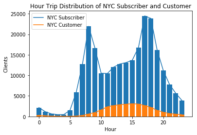

```python
# 设置饼图参数辅助赋值变量
# 把调用函数数据赋值给y的变量
x = range(len(n_data_s))
y1=n_data_s
y2=n_data_c

# 设置线形图参数
plt.plot(x, y1, label='NYC Subscriber')
plt.plot(x, y2, label='NYC Customer')

# 设置条形图参数
# 同时画线形图和条形图，刻度清晰，数据更直观
plt.bar(x, y1)
plt.bar(x, y2)

plt.legend()

# 设置图总标题:客户总月份骑行量分布图
plt.title('Hour Trip Distribution of NYC Subscriber and Customer')

# 设置横轴（X轴）标签为：月份
plt.xlabel('Hour')

# 设置纵轴（Y轴）标签为：顾客数
plt.ylabel('Clients')

# 呈现线形图和条形图
plt.show()
```

## 结论

恭喜你完成了本项目！这只是数据分析流程的一个样本，囊括了提出问题、整理数据、探索数据三大步骤。通常来讲，数据分析流程进行到这一步，你就可以进行统计检验或为数据拟合模型、得出预测，从而得出结论了。虽然还有许多潜在分析可以进行，但仅靠我们提供的这些数据是不可能完成的。例如，我们没有研究具体的地点数据。最常用的停车点在哪里？最常用的路线是什么？再如，天气也可能对每日骑客量造成很大的影响。下雨或下雪的时候，骑客量会受多大的影响？会员或散客谁更易受天气的影响？

**问题 7**：撇开共享单车数据不谈，想出一个你想应用数据科学技术的课题或领域。对于该课题，你想了解些什么？

**答案**：由于我学习的是金融专业，并且目前在金融行业工作。我最想了解的领域是金融方面。尤其是希望通过数据寻找金融工具涨跌是否有规律？如果有，规律是什么？能否通过数据，设置模型，写出自动分析预测数据的程序。

> **小贴士**：如果我们想同他人分享分析成果，我们也不一定要给他们一份 jupyter Notebook (.ipynb) 文件的副本，我们可以将 Notebook 的输出结果以某种格式输出，这样一来，就算是没有安装 Python 的人也可以打开文件。在左上方的 **文件** 菜单中找到 **下载为** 子菜单，你可以在其中选择各种更加普遍的格式，比如 HTML (.html) 或 PDF (.pdf)。你可能还需要额外的包或软件来实现这类输出。

> 如果你是通过教室的 Project Notebook 页面来进行本项目的，你也可以直接从工作空间提交本项目。 **但在此之前**，你得执行下方的代码框，为完成好的项目保存一份 HTML 的副本，并将其放到工作空间中。如果操作顺利，输出代码应为 0， 如果你点击左上角的 jupyter 图标，你就会看到工作空间的目录中出现了你的 .html 文件；或者你也可以根据上述段落提及的步骤来下载报告的 .html 格式副本，然后 *上传* 该报告到目录之中（点击 jupyter 图标来实现这一步）。

> 无论是哪个办法，一旦你在工作空间中获取了 .html 格式的报告，你就可以点击工作空间右下方的“项目提交”按钮来完成提交。

```python
from subprocess import call
call(['python', '-m', 'nbconvert', 'Bike_Share_Analysis-zh.ipynb'])
```

```
0
```